# R-kwadraat uitgelegd

← Concepten in beeld

Bij regressieanalyse schatten we een rechte die het verband tussen twee variabelen zo goed mogelijk samenvat. Maar *hoe goed* doet die rechte het eigenlijk? Is het model een grote verbetering ten opzichte van niets weten, of stelt het maar weinig voor?

Dat is precies de vraag die **R-kwadraat** (ook geschreven als $R^2$) beantwoordt. R-kwadraat is een maat voor **modelfit**: het vertelt ons welk deel van de totale variabiliteit in de uitkomstvariabele door het regressiemodel verklaard wordt.

Om R-kwadraat te begrijpen, moeten we drie bouwstenen kennen: de **TSS** (Total Sum of Squares), de **RSS** (Regression Sum of Squares) en de **SSE** (Sum of Squares of Errors). Scroll rustig door naar beneden — we bouwen dit stap voor stap op.

We starten met een vertrouwd datasetje: het verband tussen het aantal uren dat studenten gestudeerd hebben (uitgedrukt als z-score) en hun behaalde examenscore.

*Maar wat is eigenlijk een goede voorspelling als we geen regressiemodel zouden hebben?*

Het simpelste antwoord: het **gemiddelde** van de examenscore. Als je niets weet over iemand, is het gemiddelde ($\bar{y}$ = 11.36) je beste gok. We noemen dit het **nulmodel** — de horizontale stippellijn doorheen de data.

Om de variabiliteit in examenscores beter te zien, laten we de predictor even volledig links liggen. In deze figuur staat elke student als een punt op een rij — gesorteerd op observatienummer. De verticale lijn is het grand mean. De horizontale lijntjes tonen voor elke student hoe ver die afzit van dat gemiddelde.

Zo zien we puur de spreiding in de uitkomstvariabele: sommige studenten scoren ver boven het gemiddelde, anderen ver eronder. Al die afwijkingen samen vormen de totale variabiliteit die ons model probeert te verklaren.

**TSS — de totale variabiliteit.** De *Total Sum of Squares* meet hoeveel de examenscores onderling variëren. Voor elk individueel punt berekenen we de afstand tot het algemeen gemiddelde (de grand mean) $\bar{y}$, kwadrateren we die afstand, en tellen we alles op: $TSS = \sum(y_i - \bar{y})^2$.

In de figuur zie je die afstanden als verticale lijntjes van elk punt naar de stippellijn. Hoe groter de lijntjes, hoe meer variabiliteit er in de data zit.

De TSS is de totale “berg aan variabiliteit” die ons model moet proberen te verklaren.

Nu voegen we de OLS-regressielijn toe — de rechte die de predictiefouten minimaliseert.

De gele lijn is ons regressiemodel. Nu kunnen we de TSS in twee stukken opdelen: het deel dat het model *wel* verklaart, en het deel dat het model *niet* verklaart.

**SSE — wat het model niet verklaart.** De *Sum of Squares of Errors* meet de resterende variabiliteit nadat het model zijn werk heeft gedaan. Voor elk punt berekenen we de afstand van de werkelijke score tot de voorspelde score op de regressielijn: $SSE = \sum(y_i - \hat{y}_i)^2$. Dit zijn de **residuen** — de fouten die het model nog steeds maakt.

De rode lijntjes zijn de residuen. Hoe kleiner die zijn, hoe beter het model past. Maar er is ook een ander deel van de TSS — het deel dat het model wél verklaard heeft.

**RSS — wat het model wel verklaart.** De *Regression Sum of Squares* meet hoeveel variabiliteit het model wegverklaart. We berekenen voor elk punt de afstand van de voorspelde waarde $\hat{y}_i$ tot het grand mean $\bar{y}$: $RSS = \sum(\hat{y}_i - \bar{y})^2$. Als de regressielijn stijgt of daalt, liggen de voorspelde waarden ver van het grand mean — en verklaart het model veel.

De groene lijntjes zijn de RSS: de afstand tussen het nulmodel (stippellijn) en wat het regressiemodel voorspelt. Dit is de variabiliteit die het model wegverklaart ten opzichte van puur het gemiddelde gebruiken.

De drie maten hangen mooi samen: de totale variabiliteit (TSS) splitst netjes op in een verklaard deel (RSS) en een onverklaard deel (SSE).

De TSS is de volledige spreiding in de uitkomst.

De RSS is het groene stuk — de variabiliteit die het model verklaart.

De SSE is het rode stuk — de variabiliteit die het model niet verklaart.

En R-kwadraat is simpelweg de verhouding: welk aandeel van de totale taart heeft het model opgeslokt?

We kunnen dit ook stap voor stap zelf berekenen in R.

Tot slot zetten we alle drie de componenten samen in één figuur: de grijze lijntjes zijn de TSS, de rode de SSE, en de groene de RSS.

Voor deze data geldt $R^2 =$ 0.878. Dat betekent dat ons regressiemodel **87.8% van de variabiliteit** in de examenscores verklaart aan de hand van het aantal uren studeren. De overige 12.2% wordt bepaald door factoren die niet in ons model zitten.

*Hoe dichter R-kwadraat bij 1, hoe beter het model de variabiliteit verklaart. Hoe dichter bij 0, hoe minder het model toevoegt ten opzichte van het nulmodel.*

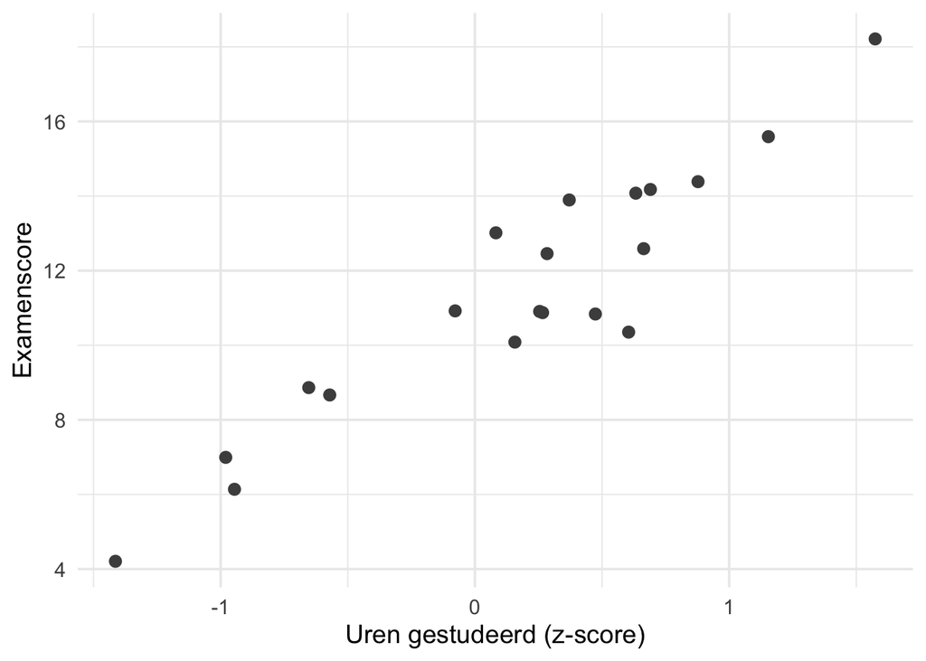

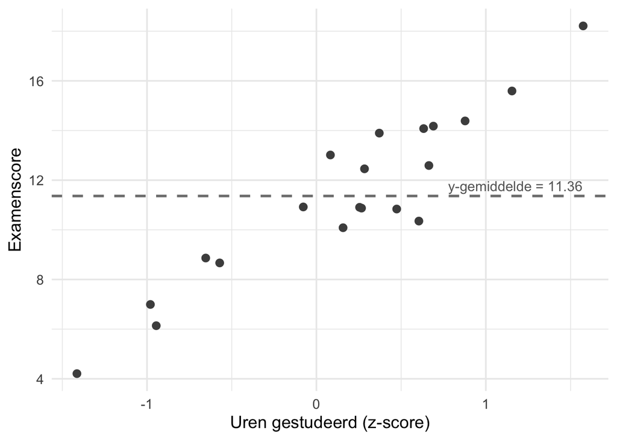

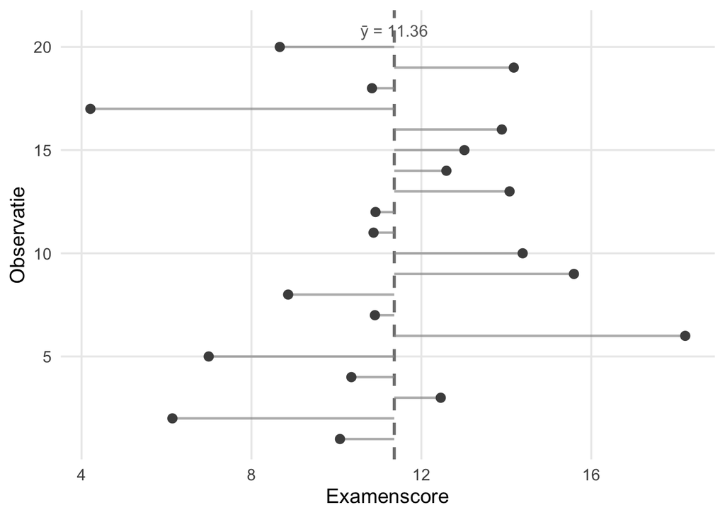

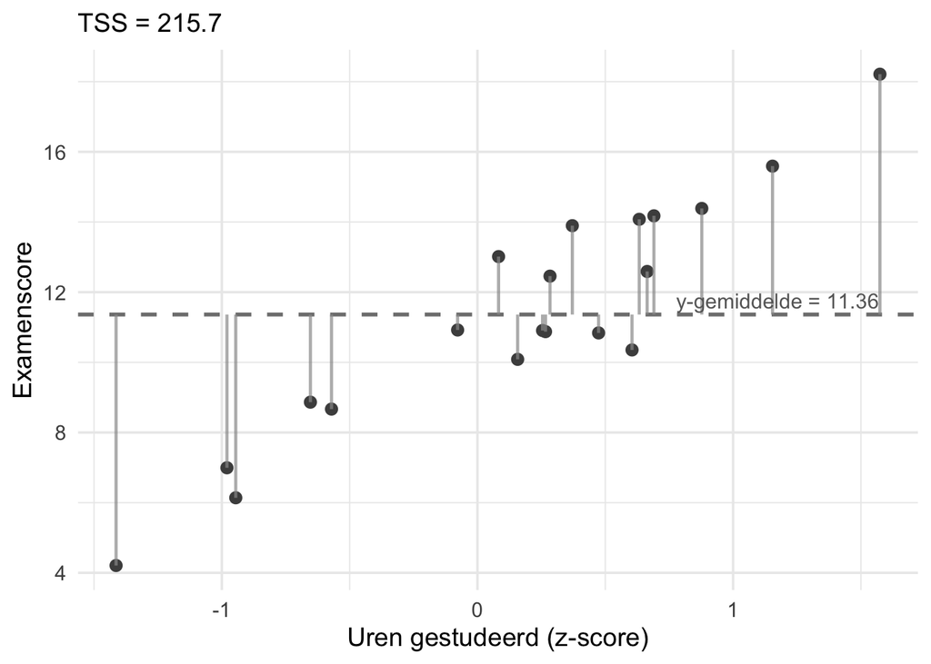

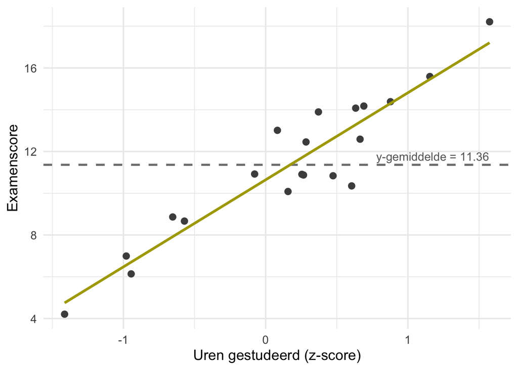

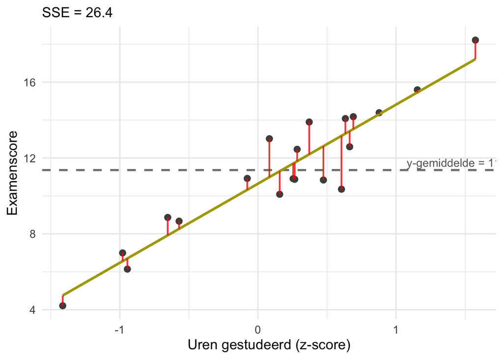

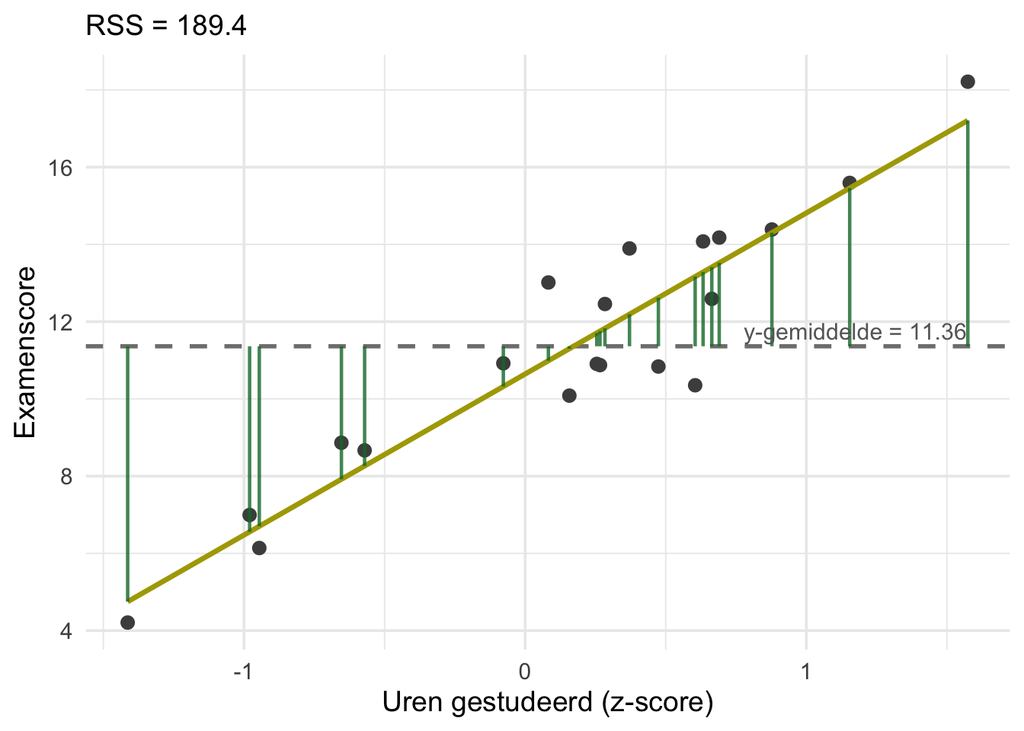

TSS = RSS + SSE  
TSS = RSS + SSE  
Totale variabiliteit = Verklaarde + Onverklaarde variabiliteit  
R-kwadraat = RSS / TSS = 1 - SSE / TSS

```r
# Model fitten
M1 <- lm(Examenscore ~ Uren, data = Data)

# Grand mean
grand_mean <- mean(Data$Examenscore)

# Voorspelde waarden uit het model
Data$Voorspelling <- fitted(M1)

# TSS: totale variabiliteit rond het grand mean
TSS <- sum((Data$Examenscore - grand_mean)^2)

# SSE: residuen — wat het model niet verklaart
SSE <- sum((Data$Examenscore - Data$Voorspelling)^2)

# RSS: wat het model wel verklaart
RSS <- sum((Data$Voorspelling - grand_mean)^2)

# R-kwadraat
R2 <- RSS / TSS
R2
```

```
[1] 0.8777937
```

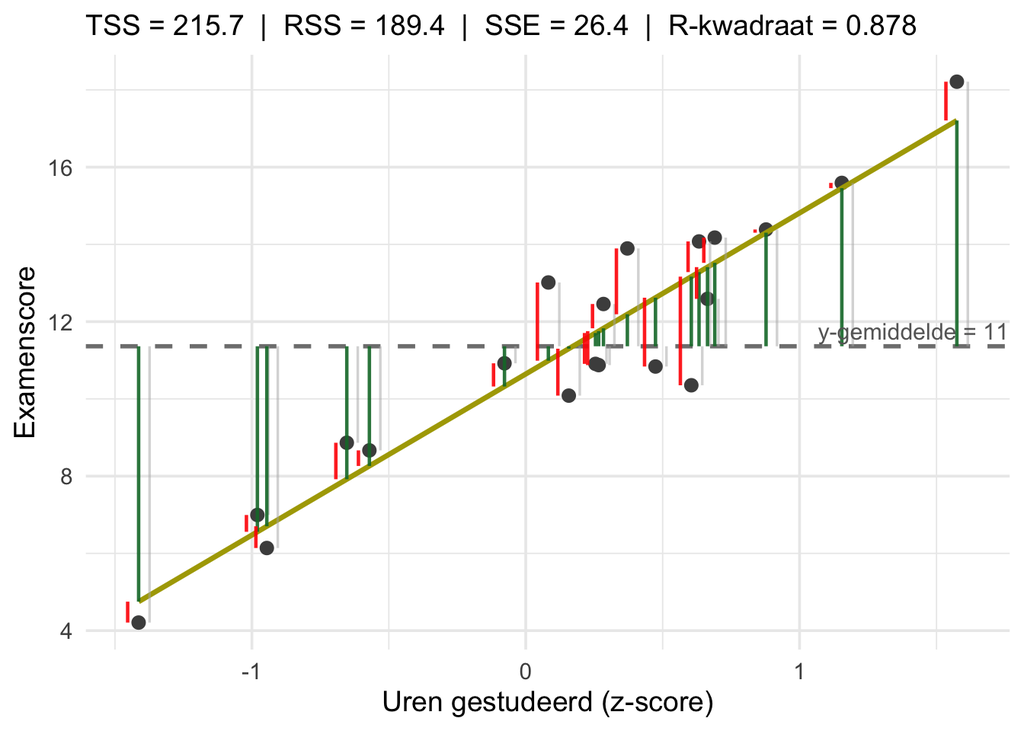